# Project 2

Thomas Girmay

# Part 1: Data Wrangling

We are looking to understand how efficient teams have been at spending money and getting wins. To accomplish this goal, we will take data from the lahman2014 sql database and observe the trends of the payroll of the team to their win ratio.

```python
import sqlite3 as sql
import matplotlib.pyplot as plt
import seaborn as sns
import numpy as np
import pandas as pd
from scipy import stats

sqlite_file = 'lahman2014.sqlite'
conn = sql.connect(sqlite_file)

salary_query = "SELECT yearID as year, teamID, sum(salary)as total_payroll FROM Salaries GROUP BY teamID, year"
winsRatioQuery = "Select teamID, yearID as year, W as wins, G as games , W*1.0/G*100 as win_percent FROM Teams GROUP BY teamID, year"

winsRatiodf = pd.read_sql(winsRatioQuery, conn)
teamSalariesdf = pd.read_sql(salary_query, conn)

display(winsRatiodf.head())
display(teamSalariesdf.head())
```

|  | teamID | year | wins | games | win_percent |
| --- | --- | --- | --- | --- | --- |
| 0 | ALT | 1884 | 6 | 25 | 24.000000 |
| 1 | ANA | 1997 | 84 | 162 | 51.851852 |
| 2 | ANA | 1998 | 85 | 162 | 52.469136 |
| 3 | ANA | 1999 | 70 | 162 | 43.209877 |
| 4 | ANA | 2000 | 82 | 162 | 50.617284 |

|  | year | teamID | total_payroll |
| --- | --- | --- | --- |
| 0 | 1985 | ATL | 14807000.0 |
| 1 | 1985 | BAL | 11560712.0 |
| 2 | 1985 | BOS | 10897560.0 |
| 3 | 1985 | CAL | 14427894.0 |
| 4 | 1985 | CHA | 9846178.0 |

We took two tables from the dataframe and kept them both indexed by teamID and year. Next, we need to merge the two dataframes with an inner join so that any missing data is filtered out.

```python
moneyBallDf = pd.merge(winsRatiodf,teamSalariesdf, how = 'inner')
moneyBallDf.set_index(["teamID","year"], inplace = True)
moneyBallDf.head(15)
```

| teamID | year | wins | games | win_percent | total_payroll |
| --- | --- | --- | --- | --- | --- |
| ANA | 1997 | 84 | 162 | 51.851852 | 31135472.0 |
|  | 1998 | 85 | 162 | 52.469136 | 41281000.0 |
|  | 1999 | 70 | 162 | 43.209877 | 55388166.0 |
|  | 2000 | 82 | 162 | 50.617284 | 51464167.0 |
|  | 2001 | 75 | 162 | 46.296296 | 47535167.0 |
|  | 2002 | 99 | 162 | 61.111111 | 61721667.0 |
|  | 2003 | 77 | 162 | 47.530864 | 79031667.0 |
|  | 2004 | 92 | 162 | 56.790123 | 100534667.0 |
| ARI | 1998 | 65 | 162 | 40.123457 | 32347000.0 |
|  | 1999 | 100 | 162 | 61.728395 | 68703999.0 |
|  | 2000 | 85 | 162 | 52.469136 | 81027833.0 |
|  | 2001 | 92 | 162 | 56.790123 | 85082999.0 |
|  | 2002 | 98 | 162 | 60.493827 | 102819999.0 |
|  | 2003 | 84 | 162 | 51.851852 | 80657000.0 |
|  | 2004 | 51 | 162 | 31.481481 | 69780750.0 |

Now we have a dataframe indexed by the teamID then the years we have data for. We can see their win percentage and the salary.

# Part 2: Analysis

Let us analyze how the total payroll increased over the years. To do so, we must create a boxplot grouped by year and select the total payroll. Lets also make the figure larger so that we can see the data mote clearly. Lets also create a scatterplot to observe the correlation between win percentage and total payroll.

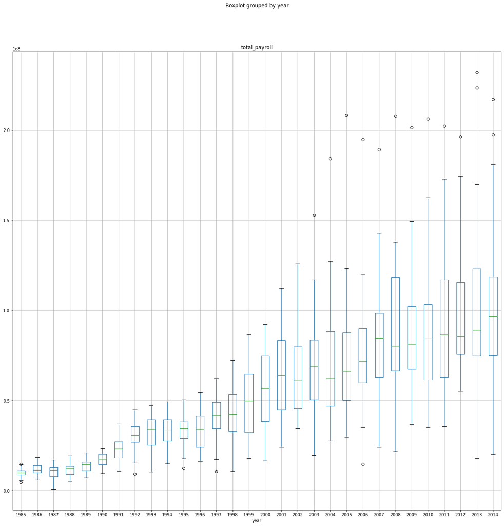

```python
moneyBallDf.reset_index().boxplot(column = 'total_payroll', by = 'year', figsize = (20,20))
```

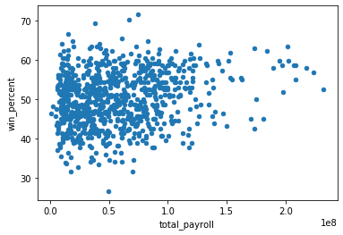

```python
moneyBallDf.reset_index().plot(x = 'total_payroll', y = 'win_percent', kind='scatter')
```

# Question 1

We can see that, over time, the average payroll increased as did the variance in payroll over the teams in a year. Let's just plot the average total payroll over time to see this trend more clearly.

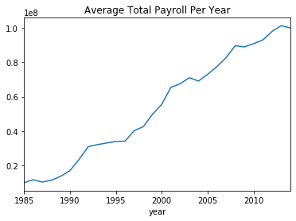

```python
moneyBallDf.groupby(level = 1)["total_payroll"].mean().plot.line(title = "Average Total Payroll Per Year")
```

# Correlation Between Payroll and Win Percentages During Time Periods

Lets observe the payroll over win percentages of the teams but split the data into discrete sets of time. To accomplish this, lets use the pd.cut() function to seperate our data into bins and store the values in a column in our MoneyBall data frame.

```python
moneyBallDf.reset_index(inplace = True)
moneyBallDf["yearFrame"] = pd.cut(moneyBallDf["year"], bins = 5, labels = ["1984-1990","1991-1996","1997-2002","2003-2008","2009-2014"])
moneyBallDf = moneyBallDf.sort_values(by = "yearFrame",ascending = True)
moneyBallDf.set_index(["yearFrame", "teamID"]).head()
```

| yearFrame | teamID | year | wins | games | win_percent | total_payroll |
| --- | --- | --- | --- | --- | --- | --- |
| 1984-1990 | OAK | 1985 | 77 | 162 | 47.530864 | 9058606.0 |
|  | TEX | 1989 | 83 | 162 | 51.234568 | 11893781.0 |
|  | TEX | 1988 | 70 | 161 | 43.478261 | 5342131.0 |
|  | TEX | 1987 | 75 | 162 | 46.296296 | 880000.0 |
|  | CAL | 1985 | 90 | 162 | 55.555556 | 14427894.0 |

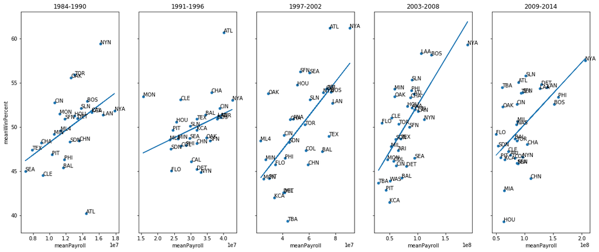

```python
fig, axes = plt.subplots(1, 5, figsize=(20, 8), sharey=True)

zPayrolldf2 = moneyBallDf.reset_index()

yearFrames = moneyBallDf["yearFrame"].unique()
meanPayrolls = []
meanWinPercent = []
#get mean payroll per time frame and then add the data as a column in the dataframe
for yearFrame in yearFrames:
    iDs = moneyBallDf["teamID"][moneyBallDf["yearFrame"] == yearFrame]

    for team in iDs:
        meanPayrolls.append(moneyBallDf[(moneyBallDf["yearFrame"] == yearFrame) & (moneyBallDf["teamID"] == team) ]['total_payroll'].mean())
        meanWinPercent.append(moneyBallDf[(moneyBallDf["yearFrame"] == yearFrame) & (moneyBallDf["teamID"] == team) ]['win_percent'].mean())

moneyBallDf["meanPayroll"] = meanPayrolls
moneyBallDf["meanWinPercent"] = meanWinPercent
uniqueIDDf = moneyBallDf.drop_duplicates(subset = ["teamID", "yearFrame"])

for ax, yearFrame in zip(axes, yearFrames):

    x = uniqueIDDf["meanPayroll"][uniqueIDDf["yearFrame"] == yearFrame]
    y = uniqueIDDf["meanWinPercent"][uniqueIDDf["yearFrame"] == yearFrame]
    iDs = uniqueIDDf["teamID"][uniqueIDDf["yearFrame"] == yearFrame]


    #Store all mean payrolls from the current YearFrame, plot, and set the title to match
    meanPayroll = uniqueIDDf[uniqueIDDf["yearFrame"] == yearFrame]
    meanPayroll.plot.scatter(x="meanPayroll", y="meanWinPercent", ax=ax)
    ax.set_title(yearFrame)


    #create regression line
    slope, intercept, r_value, p_value, std_err = stats.linregress(x,y)
    line = slope*x+intercept
    ax.plot(x, line)

    #add teamID tags to points
    for x,y,iD in zip(x,y,iDs):
        ax.annotate(iD,(x,y) )
```

These plots give us a good idea of how strong the regression is but they are difficult to use to compare between time frames. The payrolls across different periods are not in the same place on the x-axis.

# Part 3: Data Transformations

# Standardizing Over Years

Comparing payrolls over years is difficult, so lets standardize the data.

```python
zPayrolldf2["meanWinPercent"] = uniqueIDDf["meanWinPercent"]
zPayrolldf2["meanPayroll"] = uniqueIDDf["meanPayroll"]
```

```python
years = zPayrolldf["year"].unique()
payrollMeans = []
payrollStdevs = []
payrollZScores = []
zPayrolldf.sort_values(by = "year",ascending = True)

#get all means and stdevs in two lists as tuples with the year
for year in years:
    payrollMeans .append((year, zPayrolldf["total_payroll"][zPayrolldf["year"] == year].mean()))
    payrollStdevs.append((year,zPayrolldf["total_payroll"][zPayrolldf["year"] == year].std()))

#Turn the lists into dicts
payrollMeans = dict(payrollMeans)
payrollStdevs = dict(payrollStdevs)

#compure z scores and store them into df
for ind in zPayrolldf.index:
    payrollZScores.append((zPayrolldf["total_payroll"][ind] - payrollMeans[zPayrolldf["year"][ind].astype(int)] )/payrollStdevs[zPayrolldf["year"][ind].astype(int)])
zPayrolldf["payroll_zScore"] =  payrollZScores
zPayrolldf2["payroll_zScore"]= zPayrolldf["payroll_zScore"]
zPayrolldf2["efficiency"]= zPayrolldf["efficiency"]
zPayrolldf.head()
```

[output not shown]

Now that we have the Z scores, lets add the columns back to our previous datafrtame and recreate those plots to see if is clearer

```python
uniqueIDDf.reset_index()
uniqueIDDf["payroll_zScore"] = zPayrolldf["payroll_zScore"]
uniqueIDDf.head()
```

|  | teamID | year | wins | games | win_percent | total_payroll | yearFrame | meanPayroll | meanWinPercent | payroll_zScore |
| --- | --- | --- | --- | --- | --- | --- | --- | --- | --- | --- |
| 561 | OAK | 1985 | 77 | 162 | 47.530864 | 9058606.0 | 1984-1990 | 1.261824e+07 | 55.555556 | -0.411584 |
| 792 | TEX | 1989 | 83 | 162 | 51.234568 | 11893781.0 | 1984-1990 | 7.901650e+06 | 47.409452 | -0.547014 |
| 115 | CAL | 1985 | 90 | 162 | 55.555556 | 14427894.0 | 1984-1990 | 1.507731e+07 | 51.748971 | 1.761474 |
| 625 | PIT | 1989 | 74 | 164 | 45.121951 | 12737500.0 | 1984-1990 | 1.033583e+07 | 46.863590 | -0.310602 |
| 686 | SEA | 1990 | 77 | 162 | 47.530864 | 12553667.0 | 1984-1990 | 7.085071e+06 | 45.002300 | -1.198008 |

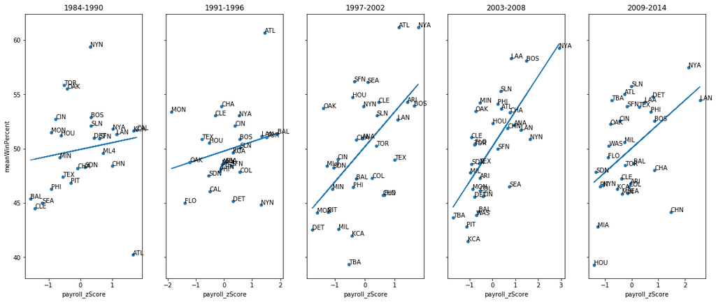

```python
fig, axes = plt.subplots(1, 5, figsize=(20, 8), sharey=True)


for ax, yearFrame in zip(axes, yearFrames):

    x = uniqueIDDf["payroll_zScore"][uniqueIDDf["yearFrame"] == yearFrame]
    y = uniqueIDDf["meanWinPercent"][uniqueIDDf["yearFrame"] == yearFrame]
    iDs = uniqueIDDf["teamID"][uniqueIDDf["yearFrame"] == yearFrame]


    #Store all mean payrolls from the current YearFrame, plot, and set the title to match
    meanPayroll = uniqueIDDf[uniqueIDDf["yearFrame"] == yearFrame]
    meanPayroll.plot.scatter(x="payroll_zScore", y="meanWinPercent", ax=ax)
    ax.set_title(yearFrame)


    #create regression line
    slope, intercept, r_value, p_value, std_err = stats.linregress(x,y)
    line = slope*x+intercept
    ax.plot(x, line)

    #add teamID tags to points
    for x,y,iD in zip(x,y,iDs):
        ax.annotate(iD,(x,y))
```

Now the data is comparable across the years because they share an x axis and we can refer to their standard deviations as terms of comparisons

# Expected Wins

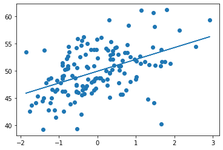

```python
ax = plt.axes()
x = uniqueIDDf["payroll_zScore"]
y = uniqueIDDf["meanWinPercent"]

ax.scatter(uniqueIDDf.reset_index()["payroll_zScore"],uniqueIDDf.reset_index()["meanWinPercent"])

slope, intercept, r_value, p_value, std_err = stats.linregress(x,y)
line = slope*x+intercept
ax.plot(x, line)
```

We can see here that teams that spend close to the average payroll in a given year will win half of their games. Next lets look at their spending efficiency.

# Spending Efficiency

Let us first compute this metric to see how efficient each team is at spending their money

```python
expectedWinPct = []
#calculate and store the expected win%
for ind in zPayrolldf.index:
    expectedWinPct.append(50+2.5*zPayrolldf["payroll_zScore"][ind])

zPayrolldf["expectedWinPct"] = expectedWinPct

#use those values to calculate the efficiency
efficiency = []
for ind in zPayrolldf.index:
    efficiency.append(zPayrolldf["win_percent"][ind] - zPayrolldf["expectedWinPct"][ind])
zPayrolldf["efficiency"] = efficiency
zPayrolldf["expectedWinPct"]

#zPayrolldf2["efficiency"]= zPayrolldf["efficiency"]
#del zPayrolldf2["meanPayroll"], zPayrolldf2["meanWinPercent"]
zPayrolldf.head()
```

|  | teamID | year | wins | games | win_percent | total_payroll | yearFrame | meanPayroll | payroll_zScore | efficiency | expectedWinPct |
| --- | --- | --- | --- | --- | --- | --- | --- | --- | --- | --- | --- |
| 561 | OAK | 1985 | 77 | 162 | 47.530864 | 9058606.0 | 1984-1990 | 12618239.5 | -0.411584 | -1.440177 | 48.971041 |
| 792 | TEX | 1989 | 83 | 162 | 51.234568 | 11893781.0 | 1984-1990 | 7901650.5 | -0.547014 | 2.602103 | 48.632465 |
| 791 | TEX | 1988 | 70 | 161 | 43.478261 | 5342131.0 | 1984-1990 | 7901650.5 | -1.834945 | -1.934376 | 45.412637 |
| 790 | TEX | 1987 | 75 | 162 | 46.296296 | 880000.0 | 1984-1990 | 7901650.5 | -2.495538 | 2.535140 | 43.761156 |
| 115 | CAL | 1985 | 90 | 162 | 55.555556 | 14427894.0 | 1984-1990 | 15077312.0 | 1.761474 | 1.151872 | 54.403684 |

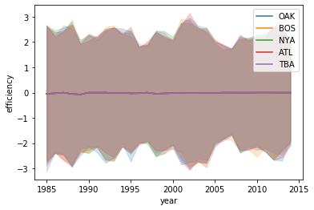

```python
teams = ["OAK", "BOS","NYA", "ATL", "TBA"]
for team in teams:
    sns.lineplot(x='year', y='efficiency', data=zPayrolldf, label = team)
```